# Risk Factor Analysis

## Outcome Variable

**Outcome Variable:** stunted

## Predictor Variables

**Intervention Variable:** mwtkg

**Adjustment Set:**

unadjusted

## Stratifying Variables

The analysis was stratified on these variable(s):

- agecat
- studyid

The following strata were considered:

- agecat: 12 months, studyid: ki0047075b-MAL-ED
- agecat: 12 months, studyid: ki1017093-NIH-Birth
- agecat: 12 months, studyid: ki1017093b-PROVIDE
- agecat: 12 months, studyid: ki1017093c-NIH-Crypto
- agecat: 12 months, studyid: ki1066203-TanzaniaChild2
- agecat: 12 months, studyid: ki1126311-ZVITAMBO
- agecat: 12 months, studyid: ki1148112-LCNI-5
- agecat: 18 months, studyid: ki0047075b-MAL-ED
- agecat: 18 months, studyid: ki1017093-NIH-Birth
- agecat: 18 months, studyid: ki1017093b-PROVIDE
- agecat: 18 months, studyid: ki1017093c-NIH-Crypto
- agecat: 18 months, studyid: ki1066203-TanzaniaChild2
- agecat: 18 months, studyid: ki1126311-ZVITAMBO
- agecat: 18 months, studyid: ki1148112-LCNI-5
- agecat: 24 months, studyid: ki0047075b-MAL-ED
- agecat: 24 months, studyid: ki1017093-NIH-Birth
- agecat: 24 months, studyid: ki1017093b-PROVIDE
- agecat: 24 months, studyid: ki1017093c-NIH-Crypto
- agecat: 24 months, studyid: ki1066203-TanzaniaChild2
- agecat: 24 months, studyid: ki1126311-ZVITAMBO
- agecat: 24 months, studyid: ki1148112-LCNI-5
- agecat: 3 months, studyid: ki0047075b-MAL-ED
- agecat: 3 months, studyid: ki1017093-NIH-Birth
- agecat: 3 months, studyid: ki1017093b-PROVIDE
- agecat: 3 months, studyid: ki1017093c-NIH-Crypto
- agecat: 3 months, studyid: ki1066203-TanzaniaChild2
- agecat: 3 months, studyid: ki1126311-ZVITAMBO
- agecat: 6 months, studyid: ki0047075b-MAL-ED
- agecat: 6 months, studyid: ki1017093-NIH-Birth
- agecat: 6 months, studyid: ki1017093b-PROVIDE
- agecat: 6 months, studyid: ki1017093c-NIH-Crypto
- agecat: 6 months, studyid: ki1066203-TanzaniaChild2
- agecat: 6 months, studyid: ki1126311-ZVITAMBO
- agecat: 6 months, studyid: ki1148112-LCNI-5
- agecat: 9 months, studyid: ki0047075b-MAL-ED
- agecat: 9 months, studyid: ki1017093-NIH-Birth
- agecat: 9 months, studyid: ki1017093b-PROVIDE
- agecat: 9 months, studyid: ki1017093c-NIH-Crypto
- agecat: 9 months, studyid: ki1066203-TanzaniaChild2
- agecat: 9 months, studyid: ki1126311-ZVITAMBO
- agecat: 9 months, studyid: ki1148112-LCNI-5
- agecat: Birth, studyid: ki0047075b-MAL-ED
- agecat: Birth, studyid: ki1017093-NIH-Birth
- agecat: Birth, studyid: ki1017093c-NIH-Crypto
- agecat: Birth, studyid: ki1126311-ZVITAMBO

### Dropped Strata

Some strata were dropped due to rare outcomes:

- agecat: Birth, studyid: ki1017093-NIH-Birth
- agecat: Birth, studyid: ki1017093c-NIH-Crypto
- agecat: Birth, studyid: ki1126311-ZVITAMBO
- agecat: 3 months, studyid: ki1017093b-PROVIDE
- agecat: 3 months, studyid: ki1066203-TanzaniaChild2
- agecat: 6 months, studyid: ki1017093b-PROVIDE
- agecat: 6 months, studyid: ki1066203-TanzaniaChild2
- agecat: 9 months, studyid: ki1017093b-PROVIDE
- agecat: 9 months, studyid: ki1066203-TanzaniaChild2
- agecat: 12 months, studyid: ki1017093b-PROVIDE
- agecat: 12 months, studyid: ki1066203-TanzaniaChild2
- agecat: 18 months, studyid: ki1066203-TanzaniaChild2
- agecat: 18 months, studyid: ki1126311-ZVITAMBO
- agecat: 24 months, studyid: ki1017093b-PROVIDE
- agecat: 24 months, studyid: ki1066203-TanzaniaChild2
- agecat: 24 months, studyid: ki1126311-ZVITAMBO

## Methods Detail

We’re interested in the causal parameters $E[Y_a]$ for all values of $a \in \mathcal{A}$. These parameters represent the mean outcome if, possibly contrary to fact, we intervened to set all units to have $A=a$. Under the randomization and positivity assumptions, these are identified by the statistical parameters $\psi_a=E_W[E_{Y|A,W}(Y|A=a,W)]$. In addition, we’re interested in the mean of $Y$, $E[Y]$ under no intervention (the observed mean). We will estimate these parameters by using SuperLearner to fit the relevant likelihood factors – $E_{Y|A,W}(Y|A=a,W)$ and $p(A=a|W)$, and then updating our likelihood fit using a joint TMLE.

For unadjusted analyses ($W=\{\}$), initial likelihoods were estimated using Lrnr_glm to estimate the simple $E(Y|A)$ and Lrnr_mean to estimate $p(A)$. For adjusted analyses, a small library containing Lrnr_glmnet, Lrnr_xgboost, and Lrnr_mean was used.

Having estimated these parameters, we will then use the delta method to estimate relative risks and attributable risks relative to a prespecified baseline level of $A$.

# Results Detail

## Results Plots

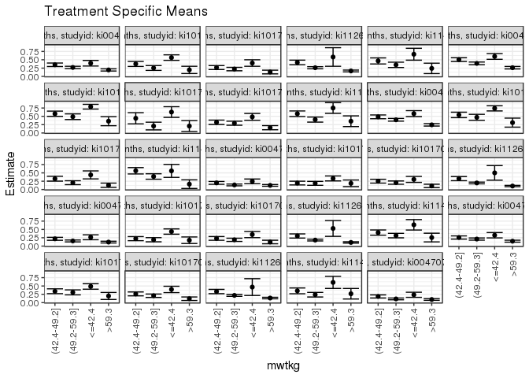

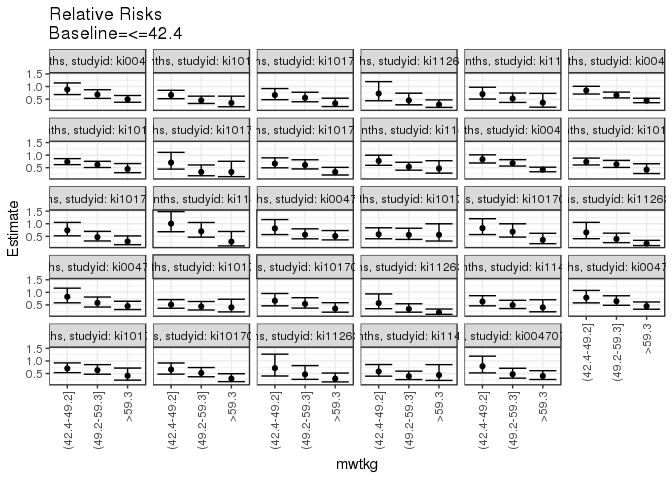

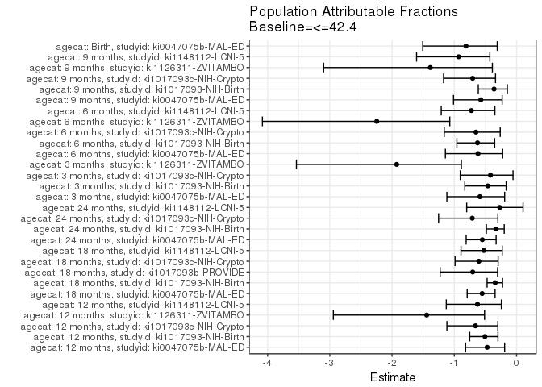

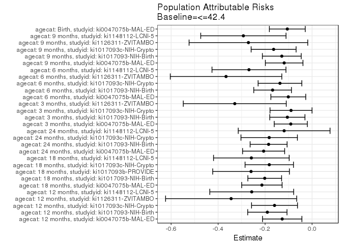

## Data Summary

| agecat | studyid | A | n | nA | nAY0 | nAY1 |
| --- | --- | --- | --- | --- | --- | --- |
| Birth | ki0047075b-MAL-ED | <=42.4 | 1425 | 119 | 91 | 28 |
| Birth | ki0047075b-MAL-ED | (42.4-49.2] | 1425 | 269 | 219 | 50 |
| Birth | ki0047075b-MAL-ED | (49.2-59.3] | 1425 | 529 | 470 | 59 |
| Birth | ki0047075b-MAL-ED | >59.3 | 1425 | 508 | 460 | 48 |
| Birth | ki1017093-NIH-Birth | <=42.4 | 28 | 12 | 12 | 0 |
| Birth | ki1017093-NIH-Birth | (42.4-49.2] | 28 | 9 | 8 | 1 |
| Birth | ki1017093-NIH-Birth | (49.2-59.3] | 28 | 7 | 7 | 0 |
| Birth | ki1017093-NIH-Birth | >59.3 | 28 | 0 | 0 | 0 |
| Birth | ki1017093b-PROVIDE | <=42.4 | 0 | 0 | 0 | 0 |
| Birth | ki1017093b-PROVIDE | (42.4-49.2] | 0 | 0 | 0 | 0 |
| Birth | ki1017093b-PROVIDE | (49.2-59.3] | 0 | 0 | 0 | 0 |
| Birth | ki1017093b-PROVIDE | >59.3 | 0 | 0 | 0 | 0 |
| Birth | ki1017093c-NIH-Crypto | <=42.4 | 27 | 8 | 6 | 2 |
| Birth | ki1017093c-NIH-Crypto | (42.4-49.2] | 27 | 9 | 7 | 2 |
| Birth | ki1017093c-NIH-Crypto | (49.2-59.3] | 27 | 7 | 6 | 1 |
| Birth | ki1017093c-NIH-Crypto | >59.3 | 27 | 3 | 3 | 0 |
| Birth | ki1066203-TanzaniaChild2 | <=42.4 | 0 | 0 | 0 | 0 |
| Birth | ki1066203-TanzaniaChild2 | (42.4-49.2] | 0 | 0 | 0 | 0 |
| Birth | ki1066203-TanzaniaChild2 | (49.2-59.3] | 0 | 0 | 0 | 0 |
| Birth | ki1066203-TanzaniaChild2 | >59.3 | 0 | 0 | 0 | 0 |
| Birth | ki1126311-ZVITAMBO | <=42.4 | 2710 | 28 | 24 | 4 |
| Birth | ki1126311-ZVITAMBO | (42.4-49.2] | 2710 | 300 | 262 | 38 |
| Birth | ki1126311-ZVITAMBO | (49.2-59.3] | 2710 | 1138 | 987 | 151 |
| Birth | ki1126311-ZVITAMBO | >59.3 | 2710 | 1244 | 1168 | 76 |
| Birth | ki1148112-LCNI-5 | <=42.4 | 0 | 0 | 0 | 0 |
| Birth | ki1148112-LCNI-5 | (42.4-49.2] | 0 | 0 | 0 | 0 |
| Birth | ki1148112-LCNI-5 | (49.2-59.3] | 0 | 0 | 0 | 0 |
| Birth | ki1148112-LCNI-5 | >59.3 | 0 | 0 | 0 | 0 |
| 3 months | ki0047075b-MAL-ED | <=42.4 | 1759 | 143 | 108 | 35 |
| 3 months | ki0047075b-MAL-ED | (42.4-49.2] | 1759 | 341 | 273 | 68 |

[output cut: 166 more lines]

## Results Table

### Parameter: TSM

| agecat | studyid | intervention_level | baseline_level | estimate | ci_lower | ci_upper |
| --- | --- | --- | --- | --- | --- | --- |
| Birth | ki0047075b-MAL-ED | <=42.4 | NA | 0.2352941 | 0.1590547 | 0.3115336 |
| Birth | ki0047075b-MAL-ED | (42.4-49.2] | NA | 0.1858736 | 0.1393708 | 0.2323764 |
| Birth | ki0047075b-MAL-ED | (49.2-59.3] | NA | 0.1115312 | 0.0846968 | 0.1383656 |
| Birth | ki0047075b-MAL-ED | >59.3 | NA | 0.0944882 | 0.0690431 | 0.1199333 |
| 3 months | ki0047075b-MAL-ED | <=42.4 | NA | 0.2447552 | 0.1742675 | 0.3152430 |
| 3 months | ki0047075b-MAL-ED | (42.4-49.2] | NA | 0.1994135 | 0.1569930 | 0.2418340 |
| 3 months | ki0047075b-MAL-ED | (49.2-59.3] | NA | 0.1382488 | 0.1117271 | 0.1647706 |
| 3 months | ki0047075b-MAL-ED | >59.3 | NA | 0.1250000 | 0.0990440 | 0.1509560 |
| 3 months | ki1017093-NIH-Birth | <=42.4 | NA | 0.3333333 | 0.2585719 | 0.4080947 |
| 3 months | ki1017093-NIH-Birth | (42.4-49.2] | NA | 0.1937173 | 0.1376202 | 0.2498144 |
| 3 months | ki1017093-NIH-Birth | (49.2-59.3] | NA | 0.1856287 | 0.1266080 | 0.2446495 |
| 3 months | ki1017093-NIH-Birth | >59.3 | NA | 0.1864407 | 0.0869761 | 0.2859052 |
| 3 months | ki1017093c-NIH-Crypto | <=42.4 | NA | 0.3039216 | 0.2146000 | 0.3932431 |
| 3 months | ki1017093c-NIH-Crypto | (42.4-49.2] | NA | 0.2511416 | 0.1936659 | 0.3086172 |
| 3 months | ki1017093c-NIH-Crypto | (49.2-59.3] | NA | 0.2076923 | 0.1583503 | 0.2570343 |
| 3 months | ki1017093c-NIH-Crypto | >59.3 | NA | 0.1088435 | 0.0584626 | 0.1592245 |
| 3 months | ki1126311-ZVITAMBO | <=42.4 | NA | 0.5000000 | 0.2808178 | 0.7191822 |
| 3 months | ki1126311-ZVITAMBO | (42.4-49.2] | NA | 0.3272727 | 0.2652553 | 0.3892901 |
| 3 months | ki1126311-ZVITAMBO | (49.2-59.3] | NA | 0.1975446 | 0.1714687 | 0.2236205 |
| 3 months | ki1126311-ZVITAMBO | >59.3 | NA | 0.1052632 | 0.0861225 | 0.1244039 |
| 6 months | ki0047075b-MAL-ED | <=42.4 | NA | 0.2647059 | 0.1905374 | 0.3388744 |
| 6 months | ki0047075b-MAL-ED | (42.4-49.2] | NA | 0.2181818 | 0.1736078 | 0.2627559 |
| 6 months | ki0047075b-MAL-ED | (49.2-59.3] | NA | 0.1542130 | 0.1259810 | 0.1824451 |
| 6 months | ki0047075b-MAL-ED | >59.3 | NA | 0.1197302 | 0.0935930 | 0.1458674 |
| 6 months | ki1017093-NIH-Birth | <=42.4 | NA | 0.4362416 | 0.3565395 | 0.5159437 |
| 6 months | ki1017093-NIH-Birth | (42.4-49.2] | NA | 0.2234637 | 0.1623820 | 0.2845453 |
| 6 months | ki1017093-NIH-Birth | (49.2-59.3] | NA | 0.1907895 | 0.1282666 | 0.2533124 |
| 6 months | ki1017093-NIH-Birth | >59.3 | NA | 0.1754386 | 0.0766084 | 0.2742688 |
| 6 months | ki1017093c-NIH-Crypto | <=42.4 | NA | 0.3465347 | 0.2536645 | 0.4394048 |
| 6 months | ki1017093c-NIH-Crypto | (42.4-49.2] | NA | 0.2304147 | 0.1743480 | 0.2864815 |

[output cut: 86 more lines]

### Parameter: E(Y)

| agecat | studyid | intervention_level | baseline_level | estimate | ci_lower | ci_upper |
| --- | --- | --- | --- | --- | --- | --- |
| Birth | ki0047075b-MAL-ED | NA | NA | 0.1298246 | 0.1274493 | 0.1321998 |
| 3 months | ki0047075b-MAL-ED | NA | NA | 0.1540648 | 0.1522789 | 0.1558507 |
| 3 months | ki1017093-NIH-Birth | NA | NA | 0.2280702 | 0.2228239 | 0.2333164 |
| 3 months | ki1017093c-NIH-Crypto | NA | NA | 0.2142857 | 0.2098078 | 0.2187637 |
| 3 months | ki1126311-ZVITAMBO | NA | NA | 0.1709040 | 0.1676488 | 0.1741591 |
| 6 months | ki0047075b-MAL-ED | NA | NA | 0.1635071 | 0.1613126 | 0.1657016 |
| 6 months | ki1017093-NIH-Birth | NA | NA | 0.2681564 | 0.2592325 | 0.2770804 |
| 6 months | ki1017093c-NIH-Crypto | NA | NA | 0.2097902 | 0.2048671 | 0.2147133 |
| 6 months | ki1126311-ZVITAMBO | NA | NA | 0.1631098 | 0.1600830 | 0.1661365 |
| 6 months | ki1148112-LCNI-5 | NA | NA | 0.3701923 | 0.3608701 | 0.3795145 |
| 9 months | ki0047075b-MAL-ED | NA | NA | 0.2069810 | 0.2043589 | 0.2096031 |
| 9 months | ki1017093-NIH-Birth | NA | NA | 0.3570020 | 0.3491641 | 0.3648399 |
| 9 months | ki1017093c-NIH-Crypto | NA | NA | 0.2322946 | 0.2261039 | 0.2384854 |
| 9 months | ki1126311-ZVITAMBO | NA | NA | 0.1956173 | 0.1926059 | 0.1986288 |
| 9 months | ki1148112-LCNI-5 | NA | NA | 0.3146417 | 0.3031999 | 0.3260836 |
| 12 months | ki0047075b-MAL-ED | NA | NA | 0.2697328 | 0.2664366 | 0.2730289 |
| 12 months | ki1017093-NIH-Birth | NA | NA | 0.3747454 | 0.3629449 | 0.3865459 |
| 12 months | ki1017093c-NIH-Crypto | NA | NA | 0.2422096 | 0.2363717 | 0.2480475 |
| 12 months | ki1126311-ZVITAMBO | NA | NA | 0.2387333 | 0.2345674 | 0.2428991 |
| 12 months | ki1148112-LCNI-5 | NA | NA | 0.4096774 | 0.3978399 | 0.4215150 |
| 18 months | ki0047075b-MAL-ED | NA | NA | 0.3863636 | 0.3809216 | 0.3918057 |
| 18 months | ki1017093-NIH-Birth | NA | NA | 0.5874730 | 0.5746714 | 0.6002746 |
| 18 months | ki1017093b-PROVIDE | NA | NA | 0.3687943 | 0.3395528 | 0.3980359 |
| 18 months | ki1017093c-NIH-Crypto | NA | NA | 0.3012618 | 0.2938232 | 0.3087004 |
| 18 months | ki1148112-LCNI-5 | NA | NA | 0.4915730 | 0.4795096 | 0.5036365 |
| 24 months | ki0047075b-MAL-ED | NA | NA | 0.3749157 | 0.3693626 | 0.3804688 |
| 24 months | ki1017093-NIH-Birth | NA | NA | 0.5547786 | 0.5420451 | 0.5675120 |
| 24 months | ki1017093c-NIH-Crypto | NA | NA | 0.2568093 | 0.2481357 | 0.2654829 |
| 24 months | ki1148112-LCNI-5 | NA | NA | 0.4410774 | 0.4268139 | 0.4553410 |

### Parameter: RR

| agecat | studyid | intervention_level | baseline_level | estimate | ci_lower | ci_upper |
| --- | --- | --- | --- | --- | --- | --- |
| Birth | ki0047075b-MAL-ED | (42.4-49.2] | <=42.4 | 0.7899628 | 0.5245918 | 1.1895749 |
| Birth | ki0047075b-MAL-ED | (49.2-59.3] | <=42.4 | 0.4740076 | 0.3166017 | 0.7096714 |
| Birth | ki0047075b-MAL-ED | >59.3 | <=42.4 | 0.4015748 | 0.2635066 | 0.6119860 |
| 3 months | ki0047075b-MAL-ED | (42.4-49.2] | <=42.4 | 0.8147465 | 0.5695449 | 1.1655129 |
| 3 months | ki0047075b-MAL-ED | (49.2-59.3] | <=42.4 | 0.5648453 | 0.3996197 | 0.7983846 |
| 3 months | ki0047075b-MAL-ED | >59.3 | <=42.4 | 0.5107143 | 0.3580829 | 0.7284042 |
| 3 months | ki1017093-NIH-Birth | (42.4-49.2] | <=42.4 | 0.5811518 | 0.4029174 | 0.8382300 |
| 3 months | ki1017093-NIH-Birth | (49.2-59.3] | <=42.4 | 0.5568862 | 0.3773845 | 0.8217674 |
| 3 months | ki1017093-NIH-Birth | >59.3 | <=42.4 | 0.5593220 | 0.3135646 | 0.9976927 |
| 3 months | ki1017093c-NIH-Crypto | (42.4-49.2] | <=42.4 | 0.8263367 | 0.5693579 | 1.1993024 |
| 3 months | ki1017093c-NIH-Crypto | (49.2-59.3] | <=42.4 | 0.6833747 | 0.4683112 | 0.9972022 |
| 3 months | ki1017093c-NIH-Crypto | >59.3 | <=42.4 | 0.3581303 | 0.2069756 | 0.6196736 |
| 3 months | ki1126311-ZVITAMBO | (42.4-49.2] | <=42.4 | 0.6545455 | 0.4060074 | 1.0552264 |
| 3 months | ki1126311-ZVITAMBO | (49.2-59.3] | <=42.4 | 0.3950893 | 0.2499609 | 0.6244798 |
| 3 months | ki1126311-ZVITAMBO | >59.3 | <=42.4 | 0.2105263 | 0.1309779 | 0.3383878 |
| 6 months | ki0047075b-MAL-ED | (42.4-49.2] | <=42.4 | 0.8242424 | 0.5827165 | 1.1658767 |
| 6 months | ki0047075b-MAL-ED | (49.2-59.3] | <=42.4 | 0.5825826 | 0.4168693 | 0.8141700 |
| 6 months | ki0047075b-MAL-ED | >59.3 | <=42.4 | 0.4523140 | 0.3170890 | 0.6452068 |
| 6 months | ki1017093-NIH-Birth | (42.4-49.2] | <=42.4 | 0.5122475 | 0.3687173 | 0.7116497 |
| 6 months | ki1017093-NIH-Birth | (49.2-59.3] | <=42.4 | 0.4373482 | 0.3005261 | 0.6364619 |
| 6 months | ki1017093-NIH-Birth | >59.3 | <=42.4 | 0.4021592 | 0.2224338 | 0.7271019 |
| 6 months | ki1017093c-NIH-Crypto | (42.4-49.2] | <=42.4 | 0.6649111 | 0.4629738 | 0.9549283 |
| 6 months | ki1017093c-NIH-Crypto | (49.2-59.3] | <=42.4 | 0.5425143 | 0.3740356 | 0.7868817 |
| 6 months | ki1017093c-NIH-Crypto | >59.3 | <=42.4 | 0.3533528 | 0.2123395 | 0.5880119 |
| 6 months | ki1126311-ZVITAMBO | (42.4-49.2] | <=42.4 | 0.5721154 | 0.3492864 | 0.9370991 |
| 6 months | ki1126311-ZVITAMBO | (49.2-59.3] | <=42.4 | 0.3405062 | 0.2125121 | 0.5455899 |
| 6 months | ki1126311-ZVITAMBO | >59.3 | <=42.4 | 0.2069173 | 0.1274480 | 0.3359392 |
| 6 months | ki1148112-LCNI-5 | (42.4-49.2] | <=42.4 | 0.6342711 | 0.4642343 | 0.8665879 |
| 6 months | ki1148112-LCNI-5 | (49.2-59.3] | <=42.4 | 0.4933837 | 0.3563206 | 0.6831700 |
| 6 months | ki1148112-LCNI-5 | >59.3 | <=42.4 | 0.4004044 | 0.2272229 | 0.7055790 |

[output cut: 57 more lines]

### Parameter: PAR

| agecat | studyid | intervention_level | baseline_level | estimate | ci_lower | ci_upper |
| --- | --- | --- | --- | --- | --- | --- |
| Birth | ki0047075b-MAL-ED | <=42.4 | NA | -0.1054696 | -0.1817460 | -0.0291931 |
| 3 months | ki0047075b-MAL-ED | <=42.4 | NA | -0.0906904 | -0.1612008 | -0.0201801 |
| 3 months | ki1017093-NIH-Birth | <=42.4 | NA | -0.1052632 | -0.1802084 | -0.0303179 |
| 3 months | ki1017093c-NIH-Crypto | <=42.4 | NA | -0.0896359 | -0.1790696 | -0.0002021 |
| 3 months | ki1126311-ZVITAMBO | <=42.4 | NA | -0.3290960 | -0.5483025 | -0.1098896 |
| 6 months | ki0047075b-MAL-ED | <=42.4 | NA | -0.1011988 | -0.1753998 | -0.0269978 |
| 6 months | ki1017093-NIH-Birth | <=42.4 | NA | -0.1680852 | -0.2482853 | -0.0878851 |
| 6 months | ki1017093c-NIH-Crypto | <=42.4 | NA | -0.1367444 | -0.2297449 | -0.0437439 |
| 6 months | ki1126311-ZVITAMBO | <=42.4 | NA | -0.3663020 | -0.6036506 | -0.1289534 |
| 6 months | ki1148112-LCNI-5 | <=42.4 | NA | -0.2686966 | -0.4260644 | -0.1113288 |
| 9 months | ki0047075b-MAL-ED | <=42.4 | NA | -0.1187766 | -0.1987936 | -0.0387595 |
| 9 months | ki1017093-NIH-Birth | <=42.4 | NA | -0.1289135 | -0.2115728 | -0.0462543 |
| 9 months | ki1017093c-NIH-Crypto | <=42.4 | NA | -0.1637450 | -0.2593940 | -0.0680960 |
| 9 months | ki1126311-ZVITAMBO | <=42.4 | NA | -0.2710493 | -0.5236021 | -0.0184966 |
| 9 months | ki1148112-LCNI-5 | <=42.4 | NA | -0.2925011 | -0.4740417 | -0.1109606 |
| 12 months | ki0047075b-MAL-ED | <=42.4 | NA | -0.1272138 | -0.2110877 | -0.0433399 |
| 12 months | ki1017093-NIH-Birth | <=42.4 | NA | -0.1904720 | -0.2741020 | -0.1068420 |
| 12 months | ki1017093c-NIH-Crypto | <=42.4 | NA | -0.1598522 | -0.2576704 | -0.0620341 |
| 12 months | ki1126311-ZVITAMBO | <=42.4 | NA | -0.3446001 | -0.6236558 | -0.0655444 |
| 12 months | ki1148112-LCNI-5 | <=42.4 | NA | -0.2569892 | -0.4354812 | -0.0784972 |
| 18 months | ki0047075b-MAL-ED | <=42.4 | NA | -0.2136364 | -0.2997178 | -0.1275550 |
| 18 months | ki1017093-NIH-Birth | <=42.4 | NA | -0.2015895 | -0.2734913 | -0.1296876 |
| 18 months | ki1017093b-PROVIDE | <=42.4 | NA | -0.2597771 | -0.4230645 | -0.0964898 |
| 18 months | ki1017093c-NIH-Crypto | <=42.4 | NA | -0.1822547 | -0.2852788 | -0.0792305 |
| 18 months | ki1148112-LCNI-5 | <=42.4 | NA | -0.2584270 | -0.4194923 | -0.0973616 |
| 24 months | ki0047075b-MAL-ED | <=42.4 | NA | -0.2062809 | -0.2958800 | -0.1166817 |
| 24 months | ki1017093-NIH-Birth | <=42.4 | NA | -0.1850588 | -0.2637198 | -0.1063979 |
| 24 months | ki1017093c-NIH-Crypto | <=42.4 | NA | -0.1825846 | -0.3027527 | -0.0624165 |
| 24 months | ki1148112-LCNI-5 | <=42.4 | NA | -0.1189226 | -0.3143523 | 0.0765072 |

### Parameter: PAF

| agecat | studyid | intervention_level | baseline_level | estimate | ci_lower | ci_upper |
| --- | --- | --- | --- | --- | --- | --- |
| Birth | ki0047075b-MAL-ED | <=42.4 | NA | -0.8124006 | -1.5072489 | -0.3101196 |
| 3 months | ki0047075b-MAL-ED | <=42.4 | NA | -0.5886512 | -1.1193537 | -0.1908407 |
| 3 months | ki1017093-NIH-Birth | <=42.4 | NA | -0.4615385 | -0.8311612 | -0.1665246 |
| 3 months | ki1017093c-NIH-Crypto | <=42.4 | NA | -0.4183007 | -0.9042690 | -0.0563512 |
| 3 months | ki1126311-ZVITAMBO | <=42.4 | NA | -1.9256198 | -3.5370837 | -0.8865095 |
| 6 months | ki0047075b-MAL-ED | <=42.4 | NA | -0.6189258 | -1.1431492 | -0.2229297 |
| 6 months | ki1017093-NIH-Birth | <=42.4 | NA | -0.6268177 | -0.9588031 | -0.3510984 |
| 6 months | ki1017093c-NIH-Crypto | <=42.4 | NA | -0.6518152 | -1.1617041 | -0.2621956 |
| 6 months | ki1126311-ZVITAMBO | <=42.4 | NA | -2.2457394 | -4.0835800 | -1.0723239 |
| 6 months | ki1148112-LCNI-5 | <=42.4 | NA | -0.7258297 | -1.2097433 | -0.3478888 |
| 9 months | ki0047075b-MAL-ED | <=42.4 | NA | -0.5738524 | -1.0124542 | -0.2308412 |
| 9 months | ki1017093-NIH-Birth | <=42.4 | NA | -0.3611003 | -0.6145472 | -0.1474388 |
| 9 months | ki1017093c-NIH-Crypto | <=42.4 | NA | -0.7049022 | -1.1727291 | -0.3378067 |
| 9 months | ki1126311-ZVITAMBO | <=42.4 | NA | -1.3856102 | -3.0993153 | -0.3883138 |
| 9 months | ki1148112-LCNI-5 | <=42.4 | NA | -0.9296322 | -1.6063492 | -0.4286192 |
| 12 months | ki0047075b-MAL-ED | <=42.4 | NA | -0.4716291 | -0.8182198 | -0.1911058 |
| 12 months | ki1017093-NIH-Birth | <=42.4 | NA | -0.5082703 | -0.7520568 | -0.2984050 |
| 12 months | ki1017093c-NIH-Crypto | <=42.4 | NA | -0.6599747 | -1.1188067 | -0.3005037 |
| 12 months | ki1126311-ZVITAMBO | <=42.4 | NA | -1.4434524 | -2.9434582 | -0.5140162 |
| 12 months | ki1148112-LCNI-5 | <=42.4 | NA | -0.6272966 | -1.1289454 | -0.2438526 |
| 18 months | ki0047075b-MAL-ED | <=42.4 | NA | -0.5529412 | -0.7932396 | -0.3448433 |
| 18 months | ki1017093-NIH-Birth | <=42.4 | NA | -0.3431468 | -0.4729870 | -0.2247517 |
| 18 months | ki1017093b-PROVIDE | <=42.4 | NA | -0.7043956 | -1.2273295 | -0.3042365 |
| 18 months | ki1017093c-NIH-Crypto | <=42.4 | NA | -0.6049709 | -0.9878463 | -0.2958405 |
| 18 months | ki1148112-LCNI-5 | <=42.4 | NA | -0.5257143 | -0.8927197 | -0.2298726 |
| 24 months | ki0047075b-MAL-ED | <=42.4 | NA | -0.5502060 | -0.8093470 | -0.3281801 |
| 24 months | ki1017093-NIH-Birth | <=42.4 | NA | -0.3335725 | -0.4847734 | -0.1977689 |
| 24 months | ki1017093c-NIH-Crypto | <=42.4 | NA | -0.7109734 | -1.2522239 | -0.2997952 |
| 24 months | ki1148112-LCNI-5 | <=42.4 | NA | -0.2696183 | -0.8008635 | 0.1049124 |